# wealth-mobility

Abhraneel Sarma

8/3/2018

If you are missing any of the packages below, use `install.packages("packagename")` to install them. The `import::` syntax requires the `import` package to be installed, and provides a simple way to import specific functions from a package without polluting your entire namespace (unlike `library()`)

```r
library(tidyverse)
library(magrittr)
library(rstan)
rstan_options(auto_write = TRUE)
options(mc.cores = parallel::detectCores())
library(brms)
library(modelr)
library(tidybayes)
library(ggstance)
```

## The Data

The de-identified data consists of the following variables: `parent's wealth quintile`, `child's wealth quintile`, `white (binary; whether the race of the person is white or not)` and `female (binary; whether the person's gender is female or not)`. We do not use female in the subsequent analysis.

```r
df <- read.csv("../data/Data.csv")

df %<>%
  na.omit() %>%
  select(id, white, female, pwealthqn, wealthqn) %>%
  rename(
    quantile = wealthqn,
    pquantile = pwealthqn
  ) %>%
  mutate(
    id = as.factor(id),
    white = as.factor(white),
    female = as.factor(female),
    pquantile = as.factor(pquantile)
  ) %>%
  as.data.frame(.)

head(df)
```

| id | white | female | pquantile | quantile |
| --- | --- | --- | --- | --- |
| 4004 | 1 | 1 | 3 | 5 |
| 4006 | 1 | 1 | 3 | 1 |
| 5003 | 1 | 0 | 2 | 3 |
| 5004 | 1 | 1 | 2 | 2 |
| 5005 | 1 | 0 | 2 | 2 |
| 6004 | 1 | 1 | 5 | 2 |

## Model

Here, we’ve used an adjacent category model `(family = "acat")` for the ordinal logistic regression. I’ve used ordinal regression because the outcome variable (a child’s wealth quantile) is discrete but ordered; as opposed to a multinomial regression which would have been used had there been no definite order in the discrete outcome variable. There are different families that can be used to model ordinal regressions, such as `cumulative`, `adjacent category` (used here), `stopping ratio`, `continuation ratio`. I do not have a strong basis for choosing this family, and a cumulative logit model or other families for ordinal regression can be used as well.

```r
get_prior(quantile ~ pquantile + cs(white), data = df, family = "acat")
```

| prior | class | coef | group | resp | dpar | nlpar | bound |
| --- | --- | --- | --- | --- | --- | --- | --- |
|  | b |  |  |  |  |  |  |
|  | b | pquantile2 |  |  |  |  |  |
|  | b | pquantile3 |  |  |  |  |  |
|  | b | pquantile4 |  |  |  |  |  |
|  | b | pquantile5 |  |  |  |  |  |
|  | b | white1 |  |  |  |  |  |
| student_t(3, 0, 10) | Intercept |  |  |  |  |  |  |

```r
# Load the model instead of running them
load("m1.cat-specific.RData")
#m1.acm = brm(quantile ~ pquantile + cs(white), data = df, family = "acat", prior=prior(normal(0, 1), class=b), iter = 5000, warmup = 2000, chains = 2)

summary(m1.acm)
```

```
##  Family: acat
##   Links: mu = logit; disc = identity
## Formula: quantile ~ pquantile + cs(white)
##    Data: df (Number of observations: 1936)
## Samples: 2 chains, each with iter = 5000; warmup = 2000; thin = 1;
##          total post-warmup samples = 6000
##
## Population-Level Effects:
##              Estimate Est.Error l-95% CI u-95% CI Eff.Sample Rhat
## Intercept[1]     0.58      0.08     0.42     0.75       3915 1.00
## Intercept[2]     0.61      0.11     0.39     0.82       3147 1.00
## Intercept[3]     1.31      0.17     0.98     1.64       2992 1.00
## Intercept[4]     1.10      0.27     0.58     1.64       3300 1.00
## pquantile2       0.19      0.06     0.08     0.30       3604 1.00
## pquantile3       0.35      0.06     0.23     0.48       3535 1.00
## pquantile4       0.59      0.07     0.45     0.72       3261 1.00
## pquantile5       0.94      0.08     0.79     1.10       4056 1.00
## white1[1]        0.38      0.13     0.13     0.64       3967 1.00
## white1[2]        0.25      0.14    -0.02     0.53       3351 1.00
## white1[3]        0.95      0.19     0.59     1.32       3051 1.00
## white1[4]        0.50      0.28    -0.03     1.08       3361 1.00
##
## Samples were drawn using sampling(NUTS). For each parameter, Eff.Sample
## is a crude measure of effective sample size, and Rhat is the potential
## scale reduction factor on split chains (at convergence, Rhat = 1).
```

```r
#This could not be uploaded to github because of size restrictions
# m1.acm1 = brm(quantile ~ pquantile + cs(white) + (1|id), data = df, family = "acat", prior=prior(normal(0, 1), class=b), iter = 5000, warmup = 2000, chains = 2)
# summary(m1.acm1)
```

```r
df %>%
  data_grid(pquantile, white) %>%
  add_fitted_draws(m1.acm, re_formula = NA) %>%
  group_by(white, pquantile, .category) %>%
  mean_qi(.value)
```

| white | pquantile | .category | .value | .lower | .upper | .width | .point | .interval |
| --- | --- | --- | --- | --- | --- | --- | --- | --- |
| 0 | 1 | 1 | 0.5056878 | 0.4690055 | 0.5440619 | 0.95 | mean | qi |
| 0 | 1 | 2 | 0.2833257 | 0.2532262 | 0.3142099 | 0.95 | mean | qi |
| 0 | 1 | 3 | 0.1544987 | 0.1311512 | 0.1802012 | 0.95 | mean | qi |
| 0 | 1 | 4 | 0.0421257 | 0.0303948 | 0.0560371 | 0.95 | mean | qi |
| 0 | 1 | 5 | 0.0143621 | 0.0083068 | 0.0223690 | 0.95 | mean | qi |
| 0 | 2 | 1 | 0.4280009 | 0.3834299 | 0.4741757 | 0.95 | mean | qi |
| 0 | 2 | 2 | 0.2904126 | 0.2595799 | 0.3219573 | 0.95 | mean | qi |
| 0 | 2 | 3 | 0.1919688 | 0.1623299 | 0.2247009 | 0.95 | mean | qi |
| 0 | 2 | 4 | 0.0634358 | 0.0460155 | 0.0847115 | 0.95 | mean | qi |
| 0 | 2 | 5 | 0.0261819 | 0.0152137 | 0.0396660 | 0.95 | mean | qi |
| 0 | 3 | 1 | 0.3607934 | 0.3082977 | 0.4127034 | 0.95 | mean | qi |
| 0 | 3 | 2 | 0.2872741 | 0.2564909 | 0.3192538 | 0.95 | mean | qi |
| 0 | 3 | 3 | 0.2230940 | 0.1882393 | 0.2607793 | 0.95 | mean | qi |
| 0 | 3 | 4 | 0.0866833 | 0.0620024 | 0.1163718 | 0.95 | mean | qi |
| 0 | 3 | 5 | 0.0421552 | 0.0235464 | 0.0662271 | 0.95 | mean | qi |
| 0 | 4 | 1 | 0.2660128 | 0.2151213 | 0.3187885 | 0.95 | mean | qi |
| 0 | 4 | 2 | 0.2667465 | 0.2329004 | 0.3006539 | 0.95 | mean | qi |
| 0 | 4 | 3 | 0.2610195 | 0.2225749 | 0.3009622 | 0.95 | mean | qi |
| 0 | 4 | 4 | 0.1278666 | 0.0934356 | 0.1699371 | 0.95 | mean | qi |
| 0 | 4 | 5 | 0.0783547 | 0.0455043 | 0.1209756 | 0.95 | mean | qi |
| 0 | 5 | 1 | 0.1427679 | 0.1018530 | 0.1881283 | 0.95 | mean | qi |
| 0 | 5 | 2 | 0.2035517 | 0.1635129 | 0.2454982 | 0.95 | mean | qi |
| 0 | 5 | 3 | 0.2834714 | 0.2403534 | 0.3271905 | 0.95 | mean | qi |
| 0 | 5 | 4 | 0.1977552 | 0.1475490 | 0.2555519 | 0.95 | mean | qi |
| 0 | 5 | 5 | 0.1724538 | 0.1048383 | 0.2549673 | 0.95 | mean | qi |
| 1 | 1 | 1 | 0.3302807 | 0.2799580 | 0.3814961 | 0.95 | mean | qi |
| 1 | 1 | 2 | 0.2713272 | 0.2402681 | 0.3045442 | 0.95 | mean | qi |
| 1 | 1 | 3 | 0.1904423 | 0.1655276 | 0.2174269 | 0.95 | mean | qi |
| 1 | 1 | 4 | 0.1336243 | 0.1091145 | 0.1608140 | 0.95 | mean | qi |
| 1 | 1 | 5 | 0.0743255 | 0.0543063 | 0.0978230 | 0.95 | mean | qi |
| 1 | 2 | 1 | 0.2473050 | 0.2083967 | 0.2876536 | 0.95 | mean | qi |
| 1 | 2 | 2 | 0.2461929 | 0.2165295 | 0.2776491 | 0.95 | mean | qi |
| 1 | 2 | 3 | 0.2092889 | 0.1844360 | 0.2350044 | 0.95 | mean | qi |
| 1 | 2 | 4 | 0.1777192 | 0.1524168 | 0.2054191 | 0.95 | mean | qi |
| 1 | 2 | 5 | 0.1194940 | 0.0943213 | 0.1480347 | 0.95 | mean | qi |
| 1 | 3 | 1 | 0.1846490 | 0.1499612 | 0.2214846 | 0.95 | mean | qi |
| 1 | 3 | 2 | 0.2157173 | 0.1865891 | 0.2456159 | 0.95 | mean | qi |
| 1 | 3 | 3 | 0.2153580 | 0.1904291 | 0.2419258 | 0.95 | mean | qi |
| 1 | 3 | 4 | 0.2147436 | 0.1869763 | 0.2444447 | 0.95 | mean | qi |
| 1 | 3 | 5 | 0.1695320 | 0.1373158 | 0.2060195 | 0.95 | mean | qi |
| 1 | 4 | 1 | 0.1115486 | 0.0862280 | 0.1388614 | 0.95 | mean | qi |
| 1 | 4 | 2 | 0.1641356 | 0.1383371 | 0.1917617 | 0.95 | mean | qi |
| 1 | 4 | 3 | 0.2065291 | 0.1817877 | 0.2333861 | 0.95 | mean | qi |
| 1 | 4 | 4 | 0.2596043 | 0.2298225 | 0.2905690 | 0.95 | mean | qi |
| 1 | 4 | 5 | 0.2581824 | 0.2179627 | 0.3016103 | 0.95 | mean | qi |
| 1 | 5 | 1 | 0.0433716 | 0.0299595 | 0.0601346 | 0.95 | mean | qi |
| 1 | 5 | 2 | 0.0906840 | 0.0701809 | 0.1132671 | 0.95 | mean | qi |
| 1 | 5 | 3 | 0.1623563 | 0.1389701 | 0.1868586 | 0.95 | mean | qi |
| 1 | 5 | 4 | 0.2909782 | 0.2602587 | 0.3234267 | 0.95 | mean | qi |
| 1 | 5 | 5 | 0.4126099 | 0.3614904 | 0.4646426 | 0.95 | mean | qi |

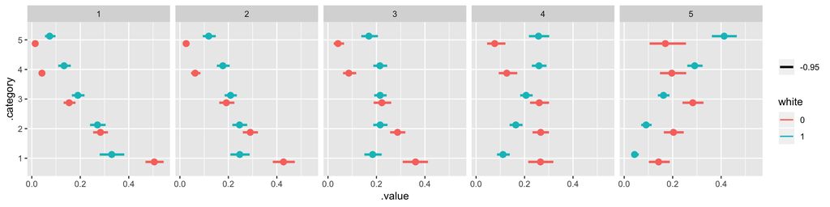

```r
df %>%
  data_grid(pquantile, white) %>%
  add_fitted_draws(m1.acm, re_formula = NA) %>%
  group_by(.category, pquantile, white) %>%
  ggplot(aes(y = .category, x = .value, color = white))+
  stat_pointintervalh(.width = 0.95, position = position_dodgev(height = 0.5), show.legend = TRUE) +
  facet_grid(.~pquantile)
```